# Assignment 2

DATA 311 - Machine Learning

Author

Maxim Storozhuk (40965642)

# Exercise 1

This is both a **classification** and **supervised** problem.

So, the answers are **A** and **C**.

# Exercise 2

```r
data <- read.csv("assignmentData/A2/churn.csv") #all data will now be stored in the "data" variable
str(data) #check for correct data types.
```

```
'data.frame':   7043 obs. of  21 variables:
 $ customerID      : chr  "7590-VHVEG" "5575-GNVDE" "3668-QPYBK" "7795-CFOCW" ...
 $ gender          : chr  "Female" "Male" "Male" "Male" ...
 $ SeniorCitizen   : int  0 0 0 0 0 0 0 0 0 0 ...
 $ Partner         : chr  "Yes" "No" "No" "No" ...
 $ Dependents      : chr  "No" "No" "No" "No" ...
 $ tenure          : int  1 34 2 45 2 8 22 10 28 62 ...
 $ PhoneService    : chr  "No" "Yes" "Yes" "No" ...
 $ MultipleLines   : chr  "No phone service" "No" "No" "No phone service" ...
 $ InternetService : chr  "DSL" "DSL" "DSL" "DSL" ...
 $ OnlineSecurity  : chr  "No" "Yes" "Yes" "Yes" ...
 $ OnlineBackup    : chr  "Yes" "No" "Yes" "No" ...
 $ DeviceProtection: chr  "No" "Yes" "No" "Yes" ...
 $ TechSupport     : chr  "No" "No" "No" "Yes" ...
 $ StreamingTV     : chr  "No" "No" "No" "No" ...
 $ StreamingMovies : chr  "No" "No" "No" "No" ...
 $ Contract        : chr  "Month-to-month" "One year" "Month-to-month" "One year" ...
 $ PaperlessBilling: chr  "Yes" "No" "Yes" "No" ...
 $ PaymentMethod   : chr  "Electronic check" "Mailed check" "Mailed check" "Bank transfer (automatic)" ...
 $ MonthlyCharges  : num  29.9 57 53.9 42.3 70.7 ...
 $ TotalCharges    : num  29.9 1889.5 108.2 1840.8 151.7 ...
 $ Churn           : chr  "No" "No" "Yes" "No" ...
```

```r
data$SeniorCitizen <- factor(data$SeniorCitizen) #SeniorCitizen is being treated as an integer rather than a categorical variable, so we will fix that
str(data) #make sure the change worked. it did
```

```
'data.frame':   7043 obs. of  21 variables:
 $ customerID      : chr  "7590-VHVEG" "5575-GNVDE" "3668-QPYBK" "7795-CFOCW" ...
 $ gender          : chr  "Female" "Male" "Male" "Male" ...
 $ SeniorCitizen   : Factor w/ 2 levels "0","1": 1 1 1 1 1 1 1 1 1 1 ...
 $ Partner         : chr  "Yes" "No" "No" "No" ...
 $ Dependents      : chr  "No" "No" "No" "No" ...
 $ tenure          : int  1 34 2 45 2 8 22 10 28 62 ...
 $ PhoneService    : chr  "No" "Yes" "Yes" "No" ...
 $ MultipleLines   : chr  "No phone service" "No" "No" "No phone service" ...
 $ InternetService : chr  "DSL" "DSL" "DSL" "DSL" ...
 $ OnlineSecurity  : chr  "No" "Yes" "Yes" "Yes" ...
 $ OnlineBackup    : chr  "Yes" "No" "Yes" "No" ...
 $ DeviceProtection: chr  "No" "Yes" "No" "Yes" ...
 $ TechSupport     : chr  "No" "No" "No" "Yes" ...
 $ StreamingTV     : chr  "No" "No" "No" "No" ...
 $ StreamingMovies : chr  "No" "No" "No" "No" ...
 $ Contract        : chr  "Month-to-month" "One year" "Month-to-month" "One year" ...
 $ PaperlessBilling: chr  "Yes" "No" "Yes" "No" ...
 $ PaymentMethod   : chr  "Electronic check" "Mailed check" "Mailed check" "Bank transfer (automatic)" ...
 $ MonthlyCharges  : num  29.9 57 53.9 42.3 70.7 ...
 $ TotalCharges    : num  29.9 1889.5 108.2 1840.8 151.7 ...
 $ Churn           : chr  "No" "No" "Yes" "No" ...
```

```r
summary(data) #check for N/A
```

```
  customerID           gender          SeniorCitizen   Partner
 Length:7043        Length:7043        0:5901        Length:7043
 Class :character   Class :character   1:1142        Class :character
 Mode  :character   Mode  :character                 Mode  :character




  Dependents            tenure      PhoneService       MultipleLines
 Length:7043        Min.   : 0.00   Length:7043        Length:7043
 Class :character   1st Qu.: 9.00   Class :character   Class :character
 Mode  :character   Median :29.00   Mode  :character   Mode  :character
                    Mean   :32.37
                    3rd Qu.:55.00
                    Max.   :72.00

 InternetService    OnlineSecurity     OnlineBackup       DeviceProtection
 Length:7043        Length:7043        Length:7043        Length:7043
 Class :character   Class :character   Class :character   Class :character
 Mode  :character   Mode  :character   Mode  :character   Mode  :character




 TechSupport        StreamingTV        StreamingMovies      Contract
 Length:7043        Length:7043        Length:7043        Length:7043
 Class :character   Class :character   Class :character   Class :character
 Mode  :character   Mode  :character   Mode  :character   Mode  :character




 PaperlessBilling   PaymentMethod      MonthlyCharges    TotalCharges
 Length:7043        Length:7043        Min.   : 18.25   Min.   :  18.8
 Class :character   Class :character   1st Qu.: 35.50   1st Qu.: 401.4
 Mode  :character   Mode  :character   Median : 70.35   Median :1397.5
                                       Mean   : 64.76   Mean   :2283.3
                                       3rd Qu.: 89.85   3rd Qu.:3794.7
                                       Max.   :118.75   Max.   :8684.8
                                                        NA's   :11
    Churn
 Length:7043
 Class :character
 Mode  :character
```

```r
data <- na.omit(data) #there are 11 N/A values in TotalCharges, so we want to remove them
summary(data) #now, we can see all observations with N/As have been removed. we have gone from 7043 to 7032 observations
```

```
  customerID           gender          SeniorCitizen   Partner
 Length:7032        Length:7032        0:5890        Length:7032
 Class :character   Class :character   1:1142        Class :character
 Mode  :character   Mode  :character                 Mode  :character



  Dependents            tenure      PhoneService       MultipleLines
 Length:7032        Min.   : 1.00   Length:7032        Length:7032
 Class :character   1st Qu.: 9.00   Class :character   Class :character
 Mode  :character   Median :29.00   Mode  :character   Mode  :character
                    Mean   :32.42
                    3rd Qu.:55.00
                    Max.   :72.00
 InternetService    OnlineSecurity     OnlineBackup       DeviceProtection
 Length:7032        Length:7032        Length:7032        Length:7032
 Class :character   Class :character   Class :character   Class :character
 Mode  :character   Mode  :character   Mode  :character   Mode  :character



 TechSupport        StreamingTV        StreamingMovies      Contract
 Length:7032        Length:7032        Length:7032        Length:7032
 Class :character   Class :character   Class :character   Class :character
 Mode  :character   Mode  :character   Mode  :character   Mode  :character



 PaperlessBilling   PaymentMethod      MonthlyCharges    TotalCharges
 Length:7032        Length:7032        Min.   : 18.25   Min.   :  18.8
 Class :character   Class :character   1st Qu.: 35.59   1st Qu.: 401.4
 Mode  :character   Mode  :character   Median : 70.35   Median :1397.5
                                       Mean   : 64.80   Mean   :2283.3
                                       3rd Qu.: 89.86   3rd Qu.:3794.7
                                       Max.   :118.75   Max.   :8684.8
    Churn
 Length:7032
 Class :character
 Mode  :character
```

# Exercise 3

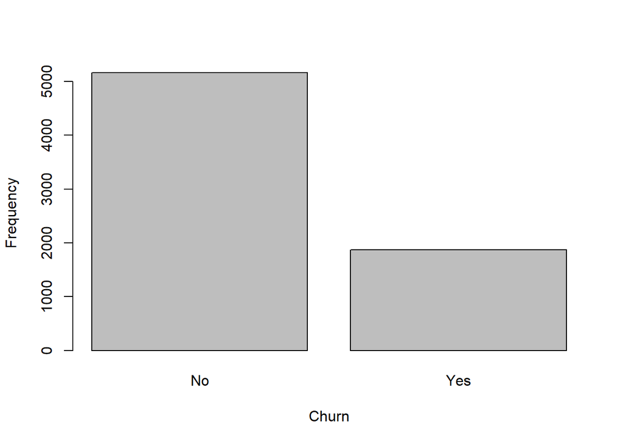

```r
library(ggplot2) #this will be used for the ggplot function
counts <- table(data$Churn) #splits churn into yes and no
barplot(counts,
        xlab = "Churn",
        ylab = "Frequency")
```

The classes are **imbalanced**. This means the model will tend to overpredict “No” since it contains a heavy majority of the observations, leading to poor performance on the minority class, “Yes”. This will lead to worse performance in some metrics such as recall. Alternate techniques will be required if we want to improve model performance.

# Exercise 4

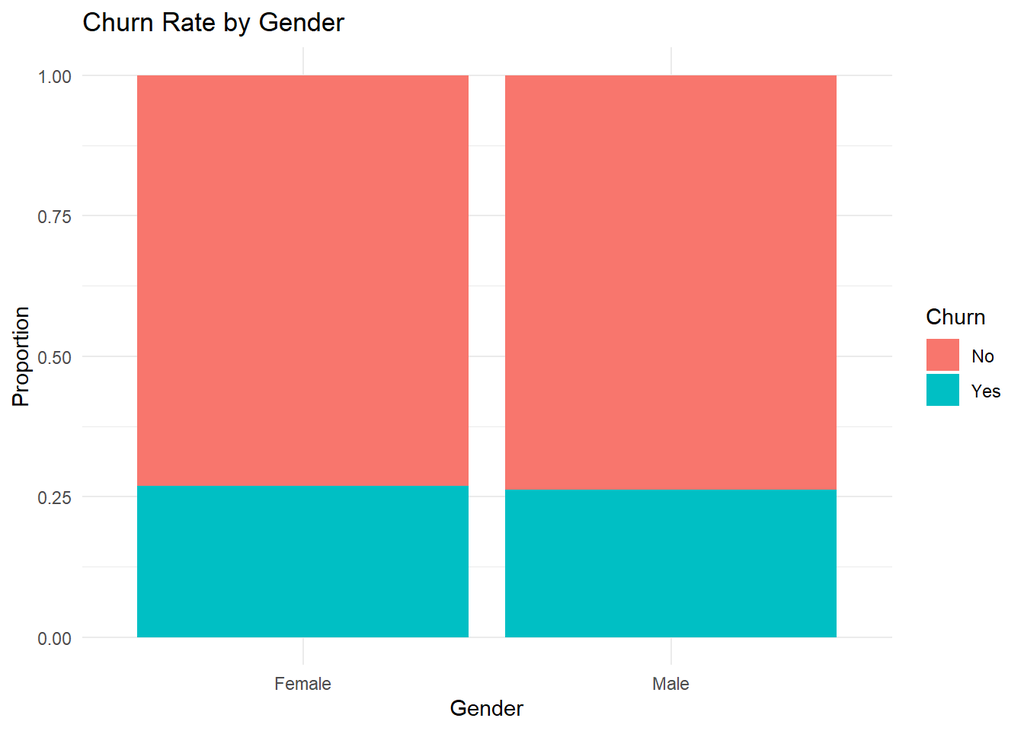

```r
ggplot(data, aes(x = gender, fill = Churn)) + #using code provided in assignment
  geom_bar(position = "fill") +
  labs(title = "Churn Rate by Gender", x = "Gender", y = "Proportion") +
  theme_minimal()
```

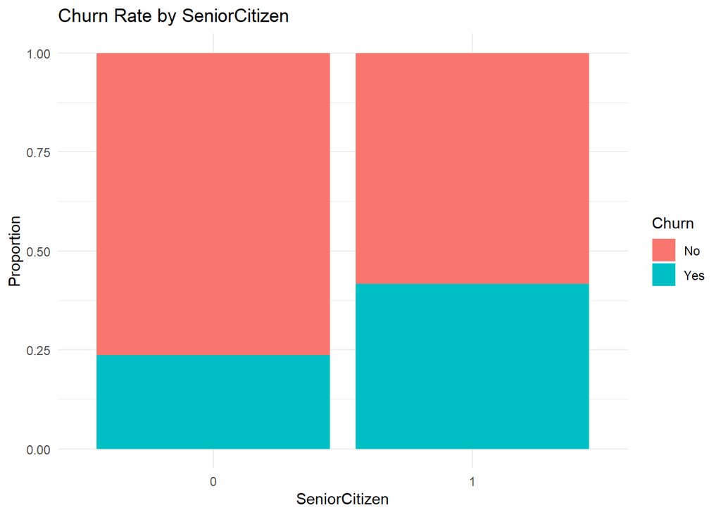

```r
ggplot(data, aes(x = SeniorCitizen, fill = Churn)) + #using code provided in assignment
  geom_bar(position = "fill") +
  labs(title = "Churn Rate by SeniorCitizen", x = "SeniorCitizen", y = "Proportion") +
  theme_minimal()
```

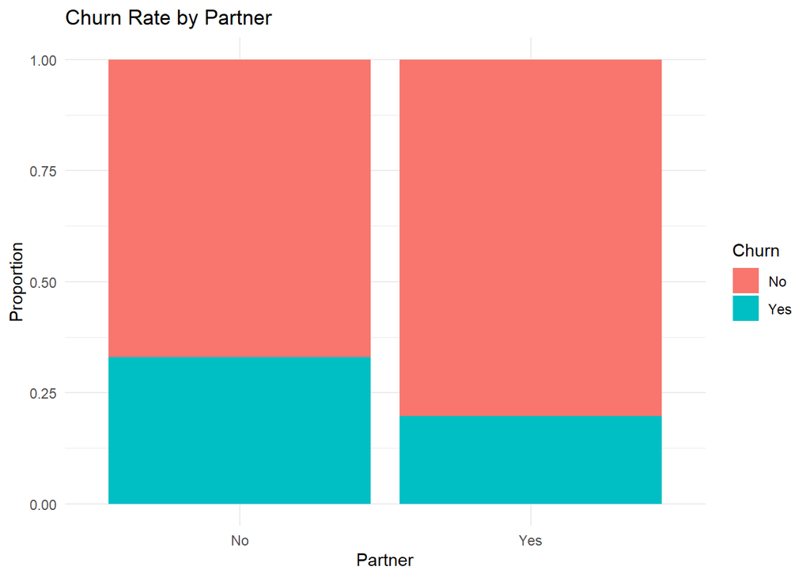

```r
ggplot(data, aes(x = Partner, fill = Churn)) + #using code provided in assignment
  geom_bar(position = "fill") +
  labs(title = "Churn Rate by Partner", x = "Partner", y = "Proportion") +
  theme_minimal()
```

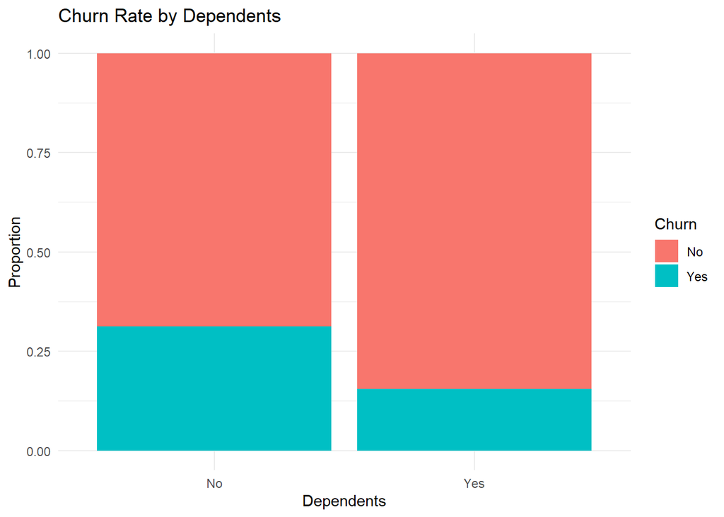

```r
ggplot(data, aes(x = Dependents, fill = Churn)) + #using code provided in assignment
  geom_bar(position = "fill") +
  labs(title = "Churn Rate by Dependents", x = "Dependents", y = "Proportion") +
  theme_minimal()
```

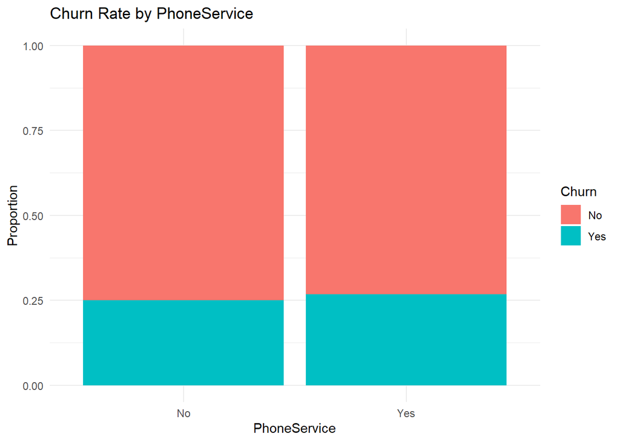

```r
ggplot(data, aes(x = PhoneService, fill = Churn)) + #using code provided in assignment
  geom_bar(position = "fill") +
  labs(title = "Churn Rate by PhoneService", x = "PhoneService", y = "Proportion") +
  theme_minimal()
```

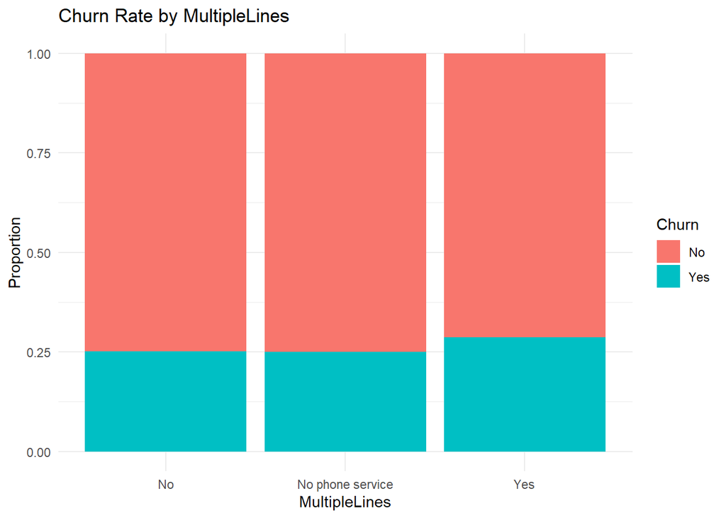

```r
ggplot(data, aes(x = MultipleLines, fill = Churn)) + #using code provided in assignment
  geom_bar(position = "fill") +
  labs(title = "Churn Rate by MultipleLines", x = "MultipleLines", y = "Proportion") +
  theme_minimal()
```

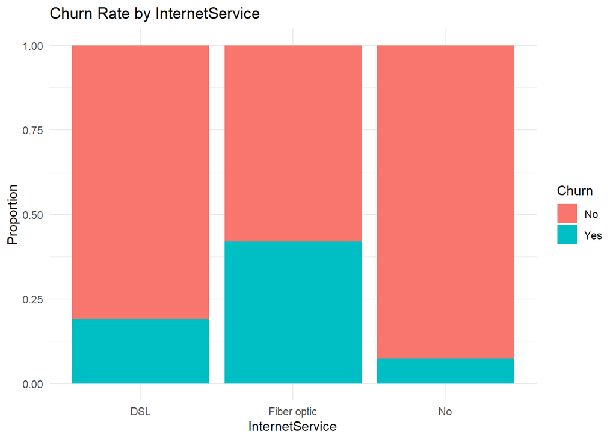

```r
ggplot(data, aes(x = InternetService, fill = Churn)) + #using code provided in assignment
  geom_bar(position = "fill") +
  labs(title = "Churn Rate by InternetService", x = "InternetService", y = "Proportion") +
  theme_minimal()
```

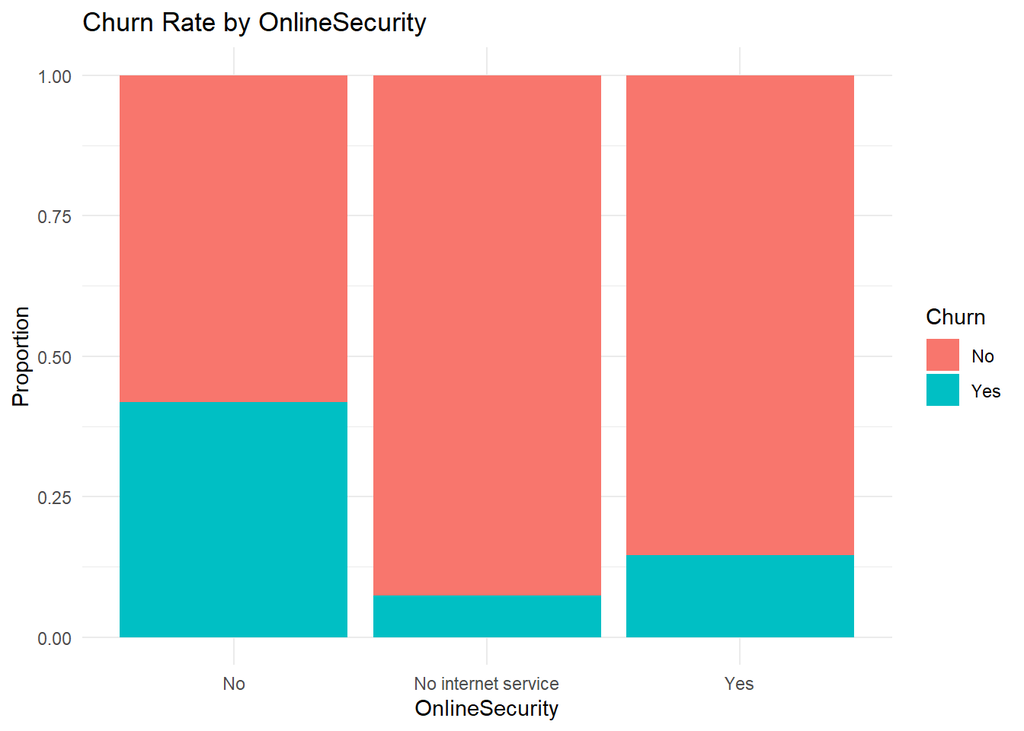

```r
ggplot(data, aes(x = OnlineSecurity, fill = Churn)) + #using code provided in assignment
  geom_bar(position = "fill") +
  labs(title = "Churn Rate by OnlineSecurity", x = "OnlineSecurity", y = "Proportion") +
  theme_minimal()
```

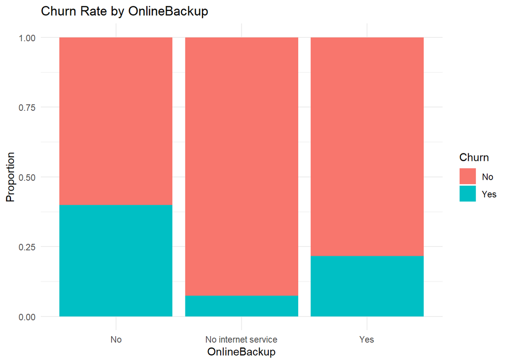

```r
ggplot(data, aes(x = OnlineBackup, fill = Churn)) + #using code provided in assignment
  geom_bar(position = "fill") +
  labs(title = "Churn Rate by OnlineBackup", x = "OnlineBackup", y = "Proportion") +
  theme_minimal()
```

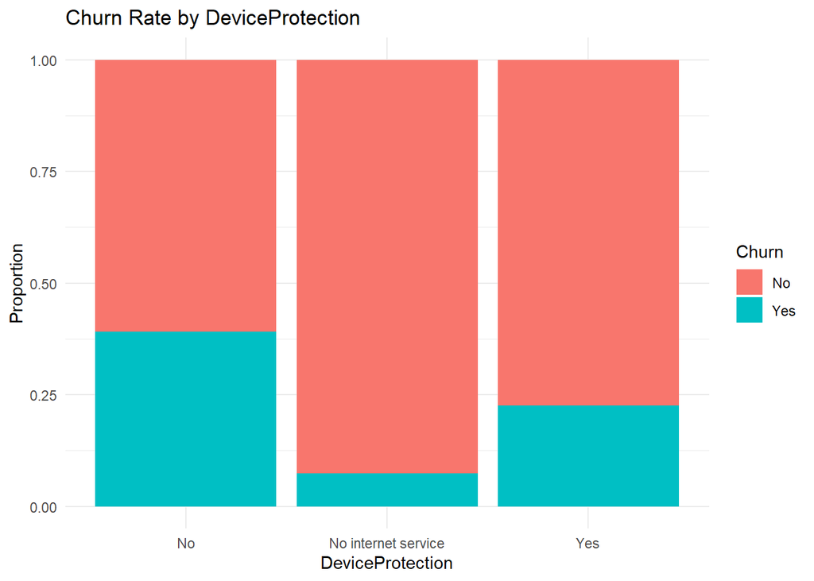

```r
ggplot(data, aes(x = DeviceProtection, fill = Churn)) + #using code provided in assignment
  geom_bar(position = "fill") +
  labs(title = "Churn Rate by DeviceProtection", x = "DeviceProtection", y = "Proportion") +
  theme_minimal()
```

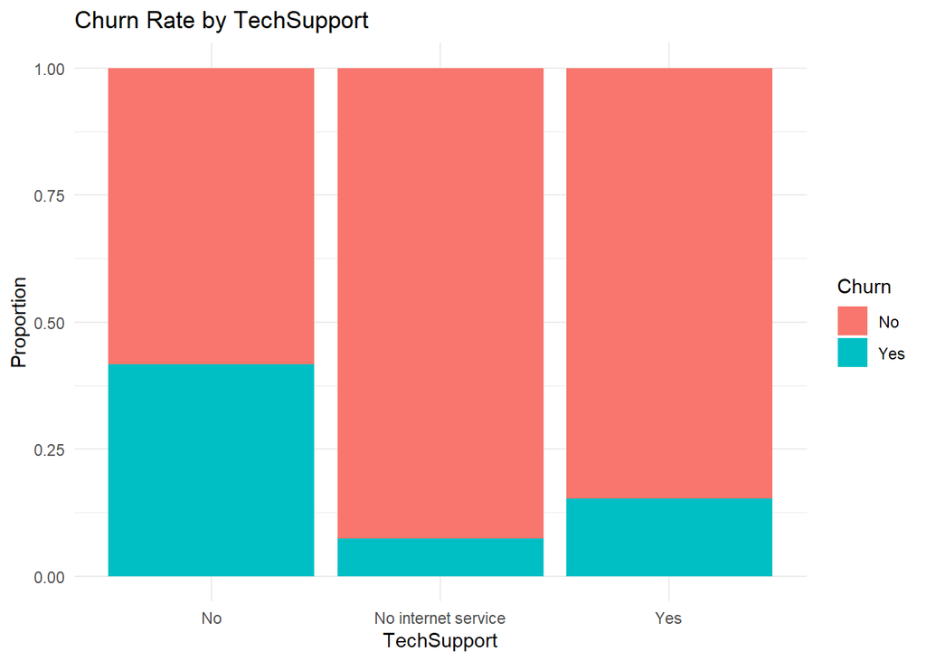

```r
ggplot(data, aes(x = TechSupport, fill = Churn)) + #using code provided in assignment
  geom_bar(position = "fill") +
  labs(title = "Churn Rate by TechSupport", x = "TechSupport", y = "Proportion") +
  theme_minimal()
```

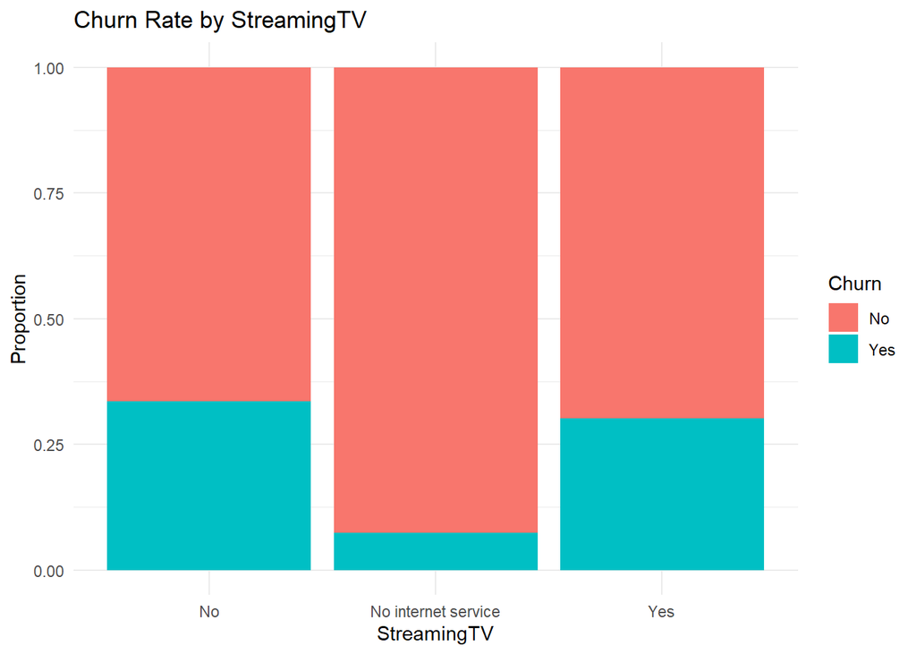

```r
ggplot(data, aes(x = StreamingTV, fill = Churn)) + #using code provided in assignment
  geom_bar(position = "fill") +
  labs(title = "Churn Rate by StreamingTV", x = "StreamingTV", y = "Proportion") +
  theme_minimal()
```

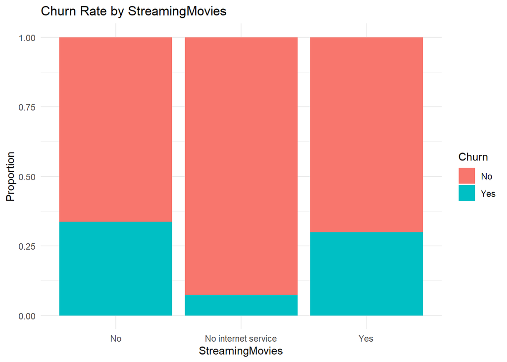

```r
ggplot(data, aes(x = StreamingMovies, fill = Churn)) + #using code provided in assignment
  geom_bar(position = "fill") +
  labs(title = "Churn Rate by StreamingMovies", x = "StreamingMovies", y = "Proportion") +
  theme_minimal()
```

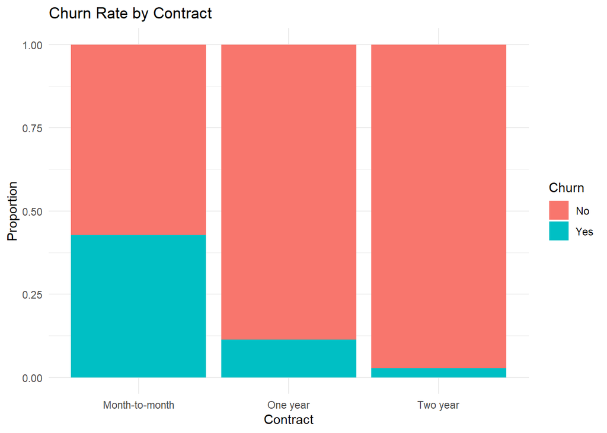

```r
ggplot(data, aes(x = Contract, fill = Churn)) + #using code provided in assignment
  geom_bar(position = "fill") +
  labs(title = "Churn Rate by Contract", x = "Contract", y = "Proportion") +
  theme_minimal()
```

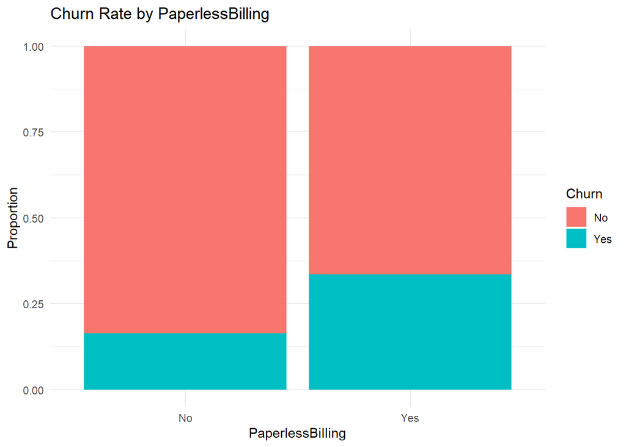

```r
ggplot(data, aes(x = PaperlessBilling, fill = Churn)) + #using code provided in assignment
  geom_bar(position = "fill") +
  labs(title = "Churn Rate by PaperlessBilling", x = "PaperlessBilling", y = "Proportion") +
  theme_minimal()
```

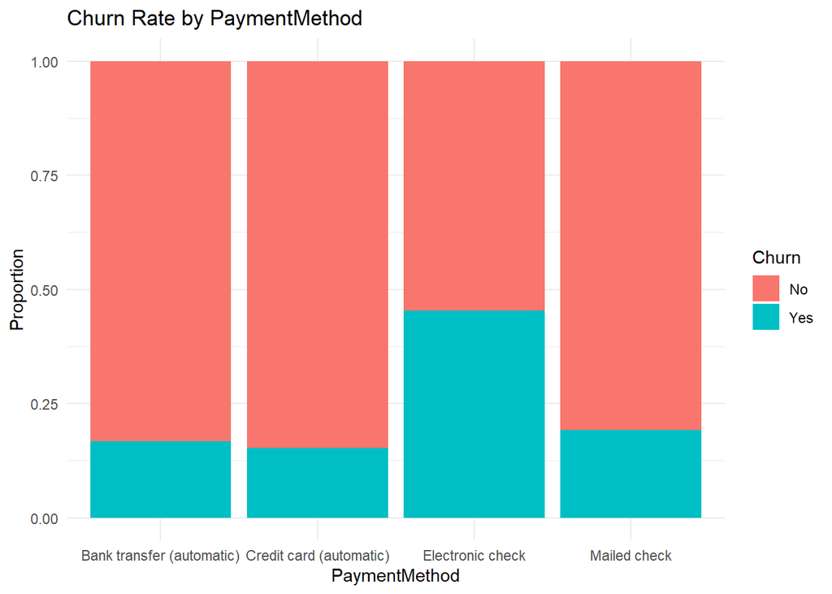

```r
ggplot(data, aes(x = PaymentMethod, fill = Churn)) + #using code provided in assignment
  geom_bar(position = "fill") +
  labs(title = "Churn Rate by PaymentMethod", x = "PaymentMethod", y = "Proportion") +
  theme_minimal()
```

Here is a list of categorical variables which seem to be correlated with churn:

- SeniorCitizen
- Partner
- Dependents
- InternetService
- OnlineSecurity
- OnlineBackup
- DeviceProtection
- TechSupport
- StreamingTV
- StreamingMovies
- Contract
- PaperlessBilling
- PaymentMethod

# Exercise 5

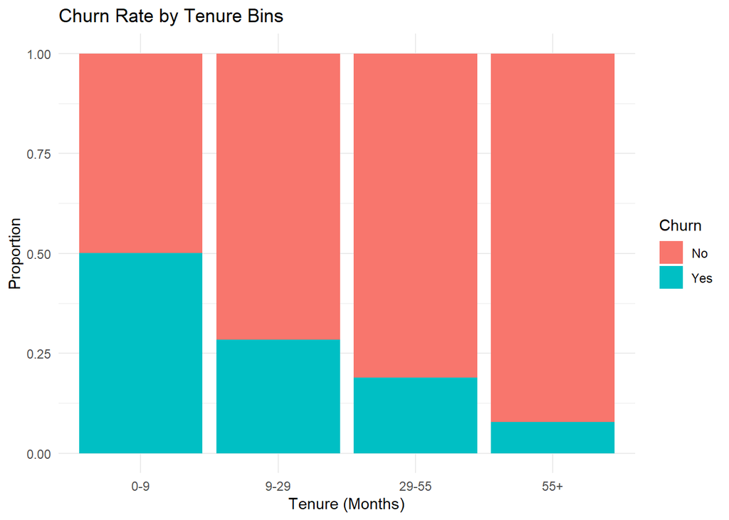

```r
# Using code provided in assignment
tenure_bins <- cut(data$tenure,
                         breaks = c(0, 9, 29, 55, Inf),
                         labels = c("0-9", "9-29", "29-55", "55+"),
                         right = TRUE,   # Include the lower bound, exclude the upper
                         include.lowest = TRUE)  # Include the lowest value

ggplot(data, aes(x = tenure_bins, fill = Churn)) +
    geom_bar(position = "fill") +
    labs(title = "Churn Rate by Tenure Bins", x = "Tenure (Months)", y = "Proportion") +
    theme_minimal()
```

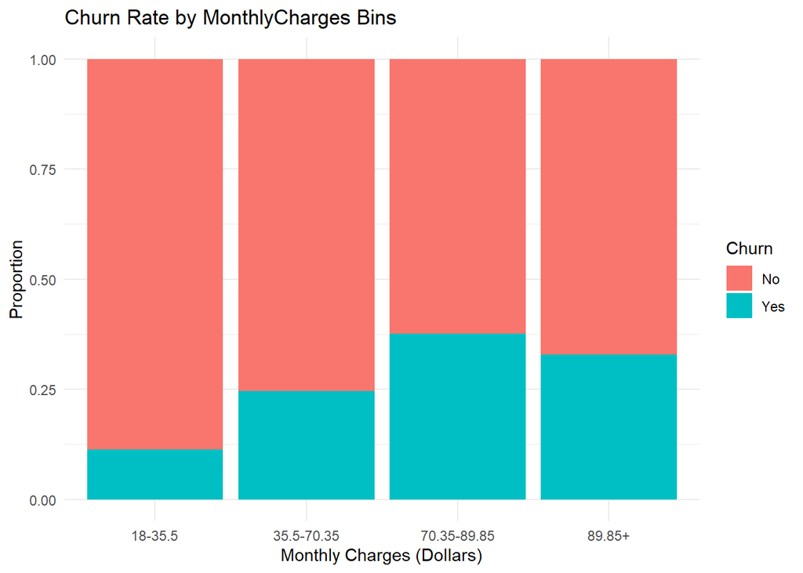

```r
MonthlyCharges_bins <- cut(data$MonthlyCharges,
                         breaks = c(18, 35.5, 70.35, 89.85, Inf),
                         labels = c("18-35.5", "35.5-70.35", "70.35-89.85", "89.85+"),
                         right = TRUE,   # Include the lower bound, exclude the upper
                         include.lowest = TRUE)  # Include the lowest value

ggplot(data, aes(x = MonthlyCharges_bins, fill = Churn)) +
    geom_bar(position = "fill") +
    labs(title = "Churn Rate by MonthlyCharges Bins", x = "Monthly Charges (Dollars)", y = "Proportion") +
    theme_minimal()
```

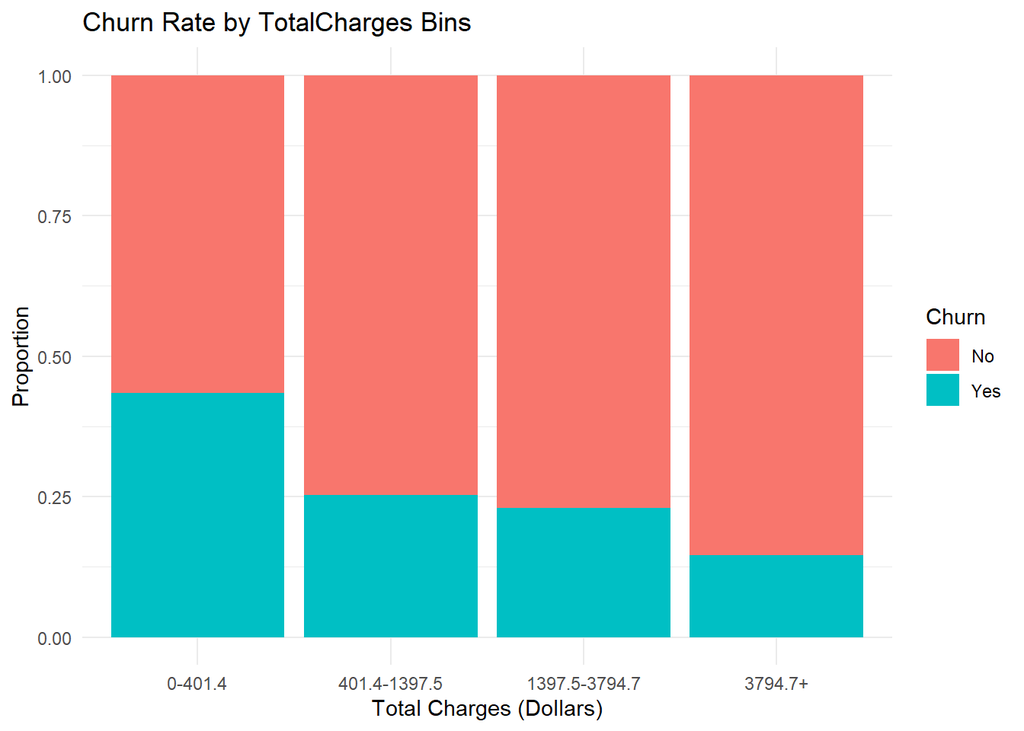

```r
TotalCharges_bins <- cut(data$TotalCharges,
                         breaks = c(0, 401.4, 1397.5, 3794.7, Inf),
                         labels = c("0-401.4", "401.4-1397.5", "1397.5-3794.7", "3794.7+"),
                         right = FALSE,   # Include the lower bound, exclude the upper
                         include.lowest = TRUE)  # Include the lowest value

ggplot(data, aes(x = TotalCharges_bins, fill = Churn)) +
    geom_bar(position = "fill") +
    labs(title = "Churn Rate by TotalCharges Bins", x = "Total Charges (Dollars)", y = "Proportion") +
    theme_minimal()
```

I decided to split the data into the four quartiles indicated in the 5 number summary in Question 2. This will be better than simply splitting in evenly spaced bins, since those will have an uneven distribution of how much data is actually considered in each of the bins.

**Tenure:**

There is a relationship between Tenure and Churn. As tenure increases, churn decreases.

**Monthly Charges:**

Customers in the first quartile of Monthly Charges are less likely to churn. There doesn’t seem to be a significant relationship involving the other 3 bins.

**Total Charges:**

There is a relationship between Total Charges and Churn. As the Total Charges increase, churn decreases.

# Exercise 6

```r
set.seed(40965642) #student number as seed for reproducibility
n <- nrow(data) #number of rows in data
#get all the indices in the corresponding storage containers
train_indices <- sample(1:n, size = round(n*0.7)) #0.7 because 70% of data should be in training set
train_data <- data[train_indices, ]
test_data <- data[-train_indices, ]
#check to make sure split was done properly
nrow(train_data)
```

```
[1] 4922
```

```r
nrow(test_data)
```

```
[1] 2110
```

I know the instructions mentioned using the validation set for tuning and model comparison, but there is nowhere in the assignment where it would actually be used. Therefore, I just used the full 30% for the testing set rather than discarding 10% of the data by making an unused validation set.

# Exercise 7

```r
modelE7 <- glm(factor(Churn)~tenure+MonthlyCharges+TotalCharges, family = "binomial", data = train_data) #fit a generalized linear model using tenure, monthlycharges, and totalcharges.
summary(modelE7)
```

```
Call:
glm(formula = factor(Churn) ~ tenure + MonthlyCharges + TotalCharges,
    family = "binomial", data = train_data)

Coefficients:
                 Estimate Std. Error z value Pr(>|z|)
(Intercept)    -1.563e+00  1.383e-01 -11.301   <2e-16 ***
tenure         -6.770e-02  6.570e-03 -10.304   <2e-16 ***
MonthlyCharges  3.056e-02  2.051e-03  14.898   <2e-16 ***
TotalCharges    1.234e-04  7.415e-05   1.664   0.0962 .
---
Signif. codes:  0 '***' 0.001 '**' 0.01 '*' 0.05 '.' 0.1 ' ' 1

(Dispersion parameter for binomial family taken to be 1)

    Null deviance: 5691.3  on 4921  degrees of freedom
Residual deviance: 4419.8  on 4918  degrees of freedom
AIC: 4427.8

Number of Fisher Scoring iterations: 6
```

# Exercise 8

The model coefficients in logistic regression represent the change in log-odds for every unit increase of its corresponding variable. This means that:

- **Tenure:** For every month that the customer has spent with the company, the log odds that the customer will churn decrease by 0.0677.
- **Monthly Charges:** For every dollar that the customer is charged monthly, the log odds that the customer will churn increase by 0.03056.
- **Total Charges:** For every dollar the customer has been charged by the company total, the log odds that the customer will churn increase by 0.0001234. However, the p-value associated with this coefficient is not significant, meaning that the coefficient does not statistically differ from 0.

# Exercise 9

I will use all variables that appeared to affect Churn from exercises 4 and 5. The way I see it, there is no reason not to include a predictor if it looks like it has a relationship with churn. It just so happens that there are 15 variables that looked to have a relationship in the visualizations.

```r
modelE9 <- glm(factor(Churn)~tenure+MonthlyCharges+SeniorCitizen+factor(Partner)+factor(Dependents)+factor(InternetService)+factor(OnlineSecurity)+factor(OnlineBackup)+factor(DeviceProtection)+factor(TechSupport)+factor(StreamingTV)+factor(StreamingMovies)+factor(Contract)+factor(PaperlessBilling)+factor(PaymentMethod), family = "binomial", data = train_data)
summary(modelE9)
```

```
Call:
glm(formula = factor(Churn) ~ tenure + MonthlyCharges + SeniorCitizen +
    factor(Partner) + factor(Dependents) + factor(InternetService) +
    factor(OnlineSecurity) + factor(OnlineBackup) + factor(DeviceProtection) +
    factor(TechSupport) + factor(StreamingTV) + factor(StreamingMovies) +
    factor(Contract) + factor(PaperlessBilling) + factor(PaymentMethod),
    family = "binomial", data = train_data)

Coefficients: (6 not defined because of singularities)
                                              Estimate Std. Error z value
(Intercept)                                   0.043620   0.286824   0.152
tenure                                       -0.033364   0.002794 -11.943
MonthlyCharges                               -0.011035   0.006334  -1.742
SeniorCitizen1                                0.170542   0.102533   1.663
factor(Partner)Yes                            0.008159   0.093278   0.087
factor(Dependents)Yes                        -0.145908   0.107318  -1.360
factor(InternetService)Fiber optic            1.236639   0.233446   5.297
factor(InternetService)No                    -1.073723   0.193509  -5.549
factor(OnlineSecurity)No internet service           NA         NA      NA
factor(OnlineSecurity)Yes                    -0.355176   0.106620  -3.331
factor(OnlineBackup)No internet service             NA         NA      NA
factor(OnlineBackup)Yes                      -0.015011   0.097443  -0.154
factor(DeviceProtection)No internet service         NA         NA      NA
factor(DeviceProtection)Yes                   0.044223   0.099751   0.443
factor(TechSupport)No internet service              NA         NA      NA
factor(TechSupport)Yes                       -0.313403   0.108874  -2.879
factor(StreamingTV)No internet service              NA         NA      NA
factor(StreamingTV)Yes                        0.363503   0.115434   3.149
factor(StreamingMovies)No internet service          NA         NA      NA
factor(StreamingMovies)Yes                    0.450234   0.114295   3.939
factor(Contract)One year                     -0.716973   0.128103  -5.597
factor(Contract)Two year                     -1.497730   0.217033  -6.901
factor(PaperlessBilling)Yes                   0.260022   0.089270   2.913
factor(PaymentMethod)Credit card (automatic) -0.190264   0.138096  -1.378
factor(PaymentMethod)Electronic check         0.272583   0.113496   2.402
factor(PaymentMethod)Mailed check            -0.098092   0.134352  -0.730
                                             Pr(>|z|)
(Intercept)                                  0.879124
tenure                                        < 2e-16 ***
MonthlyCharges                               0.081491 .
```

[output cut: 18 more lines]

```
factor(Contract)Two year                     5.17e-12 ***
factor(PaperlessBilling)Yes                  0.003582 **
factor(PaymentMethod)Credit card (automatic) 0.168276
factor(PaymentMethod)Electronic check        0.016319 *
factor(PaymentMethod)Mailed check            0.465319
---
Signif. codes:  0 '***' 0.001 '**' 0.01 '*' 0.05 '.' 0.1 ' ' 1

(Dispersion parameter for binomial family taken to be 1)

    Null deviance: 5691.3  on 4921  degrees of freedom
Residual deviance: 4061.1  on 4902  degrees of freedom
AIC: 4101.1

Number of Fisher Scoring iterations: 6
```

# Exercise 10

## Exercise 10a - Training a KNN Classifier

```r
#train knn classifier. using process outlined in lab 3
library(class)
set.seed(40965642)
attach(train_data) #so i don't have to copy and paste train_data$ and test_data$ 15 times. i know it is not recommended, but i know what i am doing in this context
train_x <- cbind(tenure, MonthlyCharges, SeniorCitizen, factor(Partner), factor(Dependents), factor(InternetService), factor(OnlineSecurity), factor(OnlineBackup), factor(DeviceProtection), factor(TechSupport), factor(StreamingTV), factor(StreamingMovies), factor(Contract), factor(PaperlessBilling), factor(PaymentMethod))
train_y <- Churn
detach(train_data) #important
attach(test_data)
test_x <- cbind(tenure, MonthlyCharges, SeniorCitizen, factor(Partner), factor(Dependents), factor(InternetService), factor(OnlineSecurity), factor(OnlineBackup), factor(DeviceProtection), factor(TechSupport), factor(StreamingTV), factor(StreamingMovies), factor(Contract), factor(PaperlessBilling), factor(PaymentMethod))
detach(test_data)

modelE10 <- knn(train = train_x, test = test_x, cl = train_y, k = 15)
```

Note: The value k = 15 was chosen without any thought. It ended up being a good choice though.

## Exercise 10b - Find optimal value of k

```r
library(caret) #createFolds function
#using process outlined in lab 4 here
k_folds <- 10 #10-fold
set.seed(40965642)
#All data is used for kfold cross validation. the split into different sets is not relevant here
folds <- createFolds(factor(data$Churn), k = k_folds, list = TRUE)
k_values <- c(3, 5, 9, 15, 25, 41, 67, 109, 175, 285) #these are the 10 k-values that will be evaluated
numKs <- length(k_values) #for indexing through k_values
errorMatrix <- matrix(NA, nrow = k_folds, ncol = length(k_values)) #errors will be stored here
for (j in 1:numKs) {
  for (i in 1:k_folds) {
    #lab 4 code is used here
    train_indicesKNN <- unlist(folds[-i])
    test_indicesKNN <- unlist(folds[i])

    train_dataKNN <- data[train_indicesKNN, ]
    test_dataKNN <- data[test_indicesKNN, ]

    #use same process as used in 10a

    attach(train_dataKNN) #so i don't have to copy and paste train_data$ and test_data$ 15 times
    train_xKNN <- cbind(tenure, MonthlyCharges, SeniorCitizen, factor(Partner), factor(Dependents), factor(InternetService), factor(OnlineSecurity), factor(OnlineBackup), factor(DeviceProtection), factor(TechSupport), factor(StreamingTV), factor(StreamingMovies), factor(Contract), factor(PaperlessBilling), factor(PaymentMethod))
    train_yKNN <- Churn
    detach(train_dataKNN)
    attach(test_dataKNN)
    test_xKNN <- cbind(tenure, MonthlyCharges, SeniorCitizen, factor(Partner), factor(Dependents), factor(InternetService), factor(OnlineSecurity), factor(OnlineBackup), factor(DeviceProtection), factor(TechSupport), factor(StreamingTV), factor(StreamingMovies), factor(Contract), factor(PaperlessBilling), factor(PaymentMethod))
    detach(test_dataKNN)
    #fit the model
    knn_model <- knn(train = train_xKNN, test = test_xKNN, cl = train_yKNN, k = k_values[j])

    # Calculate the test error for this fold and store it
    errorMatrix[i, j] <- mean(knn_model != test_dataKNN$Churn)
  }
}
avgError <- colMeans(errorMatrix, na.rm = TRUE)
optimalk <- k_values[which.min(avgError)]
optimalk
```

```
[1] 25
```

The 10-fold cross validation indicates that the optimal value of k from the tested values is **25**.

# Exercise 11

```r
library(class)
set.seed(40965642)
#we already have train_x, test_x and train_y from the previous code chunk
modelE11 <- knn(train = train_x, test = test_x, cl = train_y, k = 25)
```

# Exercise 12

The only non-deterministic component of this algorithm arises during tie-breaking. A simple example is that if k = 2 and there is 1 red and 1 blue neighbour both a distance of 1 away, then there will be a tie. This tie needs to be randomly broken. If no seed is set, then this result will be different every time, so we want to set a seed for reproducibility in case if this tie arises. For this problem specifically, it is unlikely that a tie will arise when using k = 25 and 15 predictor variables, but we need to be prepared just in case, and it is good practice.

# Exercise 13

```r
library(MASS)
modelE13 <- lda(Churn ~ tenure+TotalCharges, data = train_data) #train an LDA model
```

# Exercise 14

```r
modelE14 <- qda(Churn ~ tenure+TotalCharges, data = train_data) #train a QDA model
```

# Exercise 15

```r
predProbE7 <- predict(modelE7, newdata = test_data, type = "response")
predE7 <- factor(predProbE7>0.5, levels=c(FALSE,TRUE), labels=c("No", "Yes"))
tabE7 <- table(test_data$Churn, predE7)
tabE7
```

```
     predE7
        No  Yes
  No  1372  173
  Yes  307  258
```

```r
predProbE9 <- predict(modelE9, newdata = test_data, type = "response")
predE9 <- factor(predProbE9>0.5, levels=c(FALSE,TRUE), labels=c("No", "Yes"))
tabE9 <- table(test_data$Churn, predE9)
tabE9
```

```
     predE9
        No  Yes
  No  1353  192
  Yes  245  320
```

```r
tabE10 <- table(test_data$Churn, modelE10)
tabE10
```

```
     modelE10
        No  Yes
  No  1363  182
  Yes  283  282
```

```r
tabE11 <- table(test_data$Churn, modelE11)
tabE11
```

```
     modelE11
        No  Yes
  No  1377  168
  Yes  301  264
```

```r
predE13 <- predict(modelE13, newdata = test_data)
tabE13 <- table(test_data$Churn, predE13$class)
tabE13
```

```
        No  Yes
  No  1439  106
  Yes  417  148
```

```r
predE14 <- predict(modelE14, newdata = test_data)
tabE14 <- table(test_data$Churn, predE14$class)
tabE14
```

```
        No  Yes
  No  1053  492
  Yes  157  408
```

# Exercise 16

```r
library(knitr)
#recall = a/(a+b), where a = true positive, and b = false negative
#in these confusion matrices, a will be in [2,2], while b will be in [2,1]

rE7 <- tabE7[2,2] / (tabE7[2,2] + tabE7[2,1])
rE9 <- tabE9[2,2] / (tabE9[2,2] + tabE9[2,1])
rE10 <- tabE10[2,2] / (tabE10[2,2] + tabE10[2,1])
rE11 <- tabE11[2,2] / (tabE11[2,2] + tabE11[2,1])
rE13 <- tabE13[2,2] / (tabE13[2,2] + tabE13[2,1])
rE14 <- tabE14[2,2] / (tabE14[2,2] + tabE14[2,1])

e16 <- data.frame(
  Model = c("Basic Logistic Regression. Exercise 7", "My Logistic Regression. Exercise 9", "KNN Model, k = 15. Exercise 10", "KNN Model, k = 25. Exercise 11", "LDA. Exercise 13", "QDA. Exercise 14"),
  Recall = c(rE7, rE9, rE10, rE11, rE13, rE14)
)
kable(e16)
```

| Model | Recall |
| --- | --- |
| Basic Logistic Regression. Exercise 7 | 0.4566372 |
| My Logistic Regression. Exercise 9 | 0.5663717 |
| KNN Model, k = 15. Exercise 10 | 0.4991150 |
| KNN Model, k = 25. Exercise 11 | 0.4672566 |
| LDA. Exercise 13 | 0.2619469 |
| QDA. Exercise 14 | 0.7221239 |

Interestingly, k = 15 has a higher recall than k = 25. And, if you look at the confusion matrices in Exercise 15, it has a higher accuracy as well. This can happen because the k-fold cross validation uses “folds” as the the testing set, and all other data in the training set. Just training the KNN model normally uses a specific training set and a specific testing set. k = 25 generally performs better, but the way that the training and testing split worked out with my student number seed, k = 15 performed better under those specific circumstances.

QDA performed very well here. If you look at the confusion matrices, you can see that it had a lot of false positives in addition to its true positives. It performed very well on recall which is the metric we care about, but it would struggle in other metrics if we were to evaluate them.

# Exercise 17

```r
set.seed(40965642)
B <- 1000 #number of bootstrap samples to be taken
recalls <- numeric(1000) #all calculates recalls will be stored here
ntrain <- nrow(train_data) #size of training set

for(i in 1:B){
  boot_indices <- sample(1:ntrain, ntrain, replace = TRUE)  #sample the size of the training set indices with replacement
  boot_data <- train_data[boot_indices, ]

  qdaMod <- qda(Churn~tenure+TotalCharges, data = boot_data) #train QDA model
  predqda <- predict(qdaMod, newdata = test_data) #predict
  tabqda <- table(test_data$Churn, predqda$class) #create confusion matrix
  recalls[i] <- tabqda[2,2] / (tabqda[2,2]+tabqda[2,1]) #calculate recall and store in recall container
}
meanRec <- mean(recalls) #mean recall from all 1000 samples
stdevRec <- sd(recalls) #standard deviation of the recall from the 1000 samples
meanRec
```

```
[1] 0.7157699
```

```r
stdevRec
```

```
[1] 0.009838352
```

```r
lowCI <- meanRec - stdevRec*1.96 #calculate 95% confidence interval lower bound
highCI <- meanRec + stdevRec*1.96 #calculate 95% confidence interval upper bound
lowCI
```

```
[1] 0.6964867
```

```r
highCI
```

```
[1] 0.7350531
```

The standard deviation for recall is **0.009838352**.

The 95% confidence interval for recall is **0.6964867-0.7350531**. This means that we are 95% sure that the mean for recall using the QDA model lies within the interval. This aligns with the result in Exercise 14/16. The recall of 0.7221239 lies within this confidence interval.